# Wk7d2 HW

Peter Menzies

01/12/2020

```r
library(tidyverse)
library(lubridate)
library(tsibble)
library(tsibbledata)
library(fable)
```

# MVP

### 1

```r
bikes <- nyc_bikes %>%
  mutate(year = year(start_time),
         month = month(start_time, label = T),
         date = date(start_time))
```

### 2

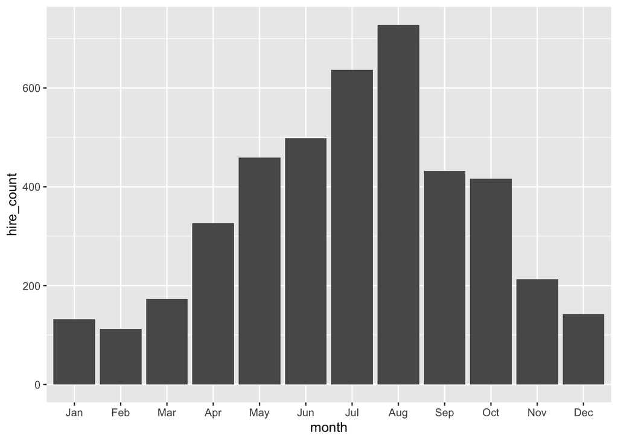

```r
bikes %>%
  index_by(month) %>%
  summarise(hire_count = n()) %>%
  ggplot() +
  aes(x = month, y = hire_count) +
  geom_col()
```

- Probably not adequete for an accurate forecast, I’d prefer to have more than one years worth of data to do that
- However it does give a decent impression of the trend that more bikes are hired in the Summer months than over Winter.

###3

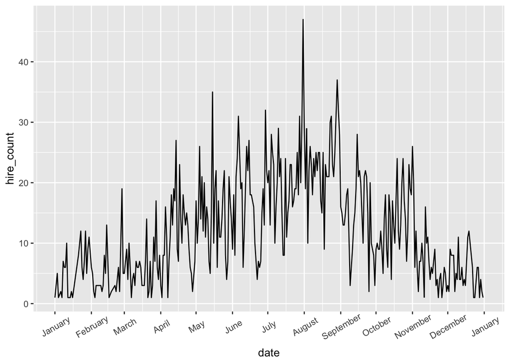

```r
bikes_date_count <- bikes %>%
  index_by(date) %>%
  summarise(hire_count = n())

bikes_date_count %>%
  ggplot() +
  aes(x = date, y = hire_count) +
  geom_line() +
  scale_x_date(breaks = "1 month",
                   labels = month,
                   date_labels = "%B") +
  theme(axis.text.x = element_text(angle = 30, vjust = 0.7))
```

- Similar trend of increased hires in Summer
- Shows there is significant variation in hire numbers within each month, perhaps cyclical with each week.
- More data points so probably better for forecasting but I would still prefer to have multiple years of data.

### 4

```r
bikes_filled <- bikes_date_count %>%
  fill_gaps(hire_count = 0)

# 0 chosen as I assume there were no hires on these dates and that is why they were not included. Using the median I feel would falsely inflate the hire count.

model <- bikes_filled %>%
  model(
    mean_model = MEAN(hire_count),
    naive_model = NAIVE(hire_count),
    snaive_model = SNAIVE(hire_count),
    arima_model = ARIMA(hire_count)
  )
```

### 5

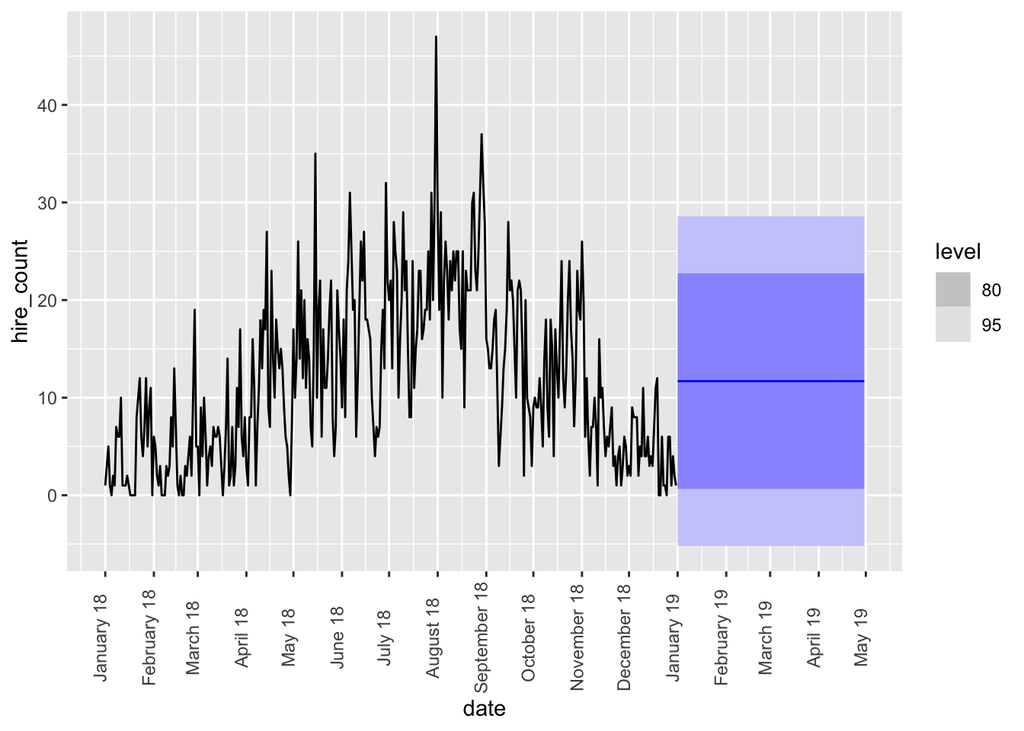

```r
forecast_mean <- model %>%
  select(mean_model) %>%
  forecast(h = 120)

forecast_mean %>%
  autoplot(bikes_filled) +
  scale_x_date(breaks = "1 month",
                   date_labels = "%B %y") +
  theme(axis.text.x = element_text(angle = 90, vjust = 0.1))
```

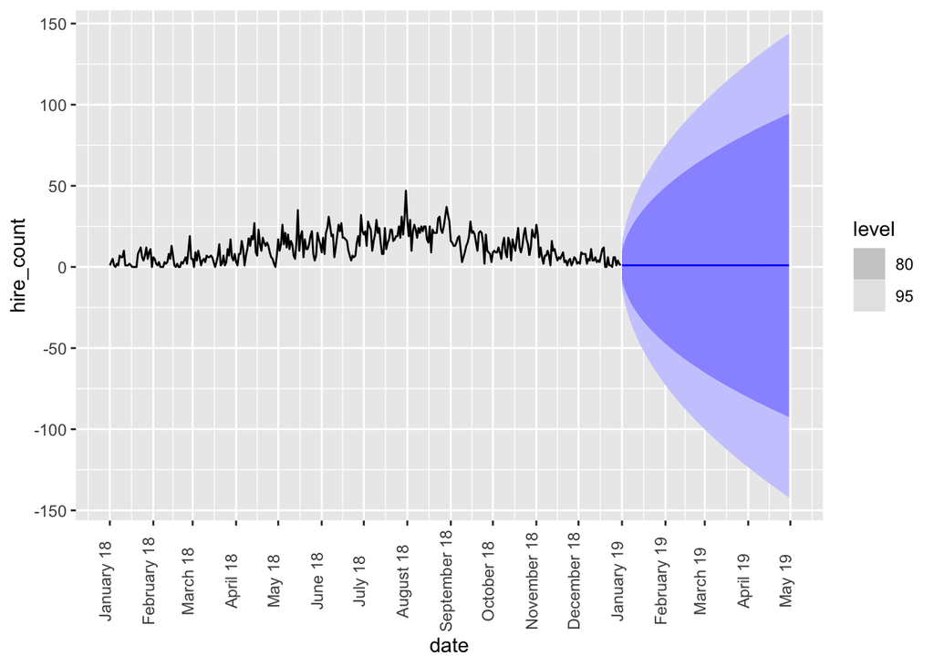

```r
forecast_naive <- model %>%
  select(naive_model) %>%
  forecast(h = 120)

forecast_naive %>%
  autoplot(bikes_filled) +
  scale_x_date(breaks = "1 month",
                   date_labels = "%B %y") +
  theme(axis.text.x = element_text(angle = 90, vjust = 0.1))
```

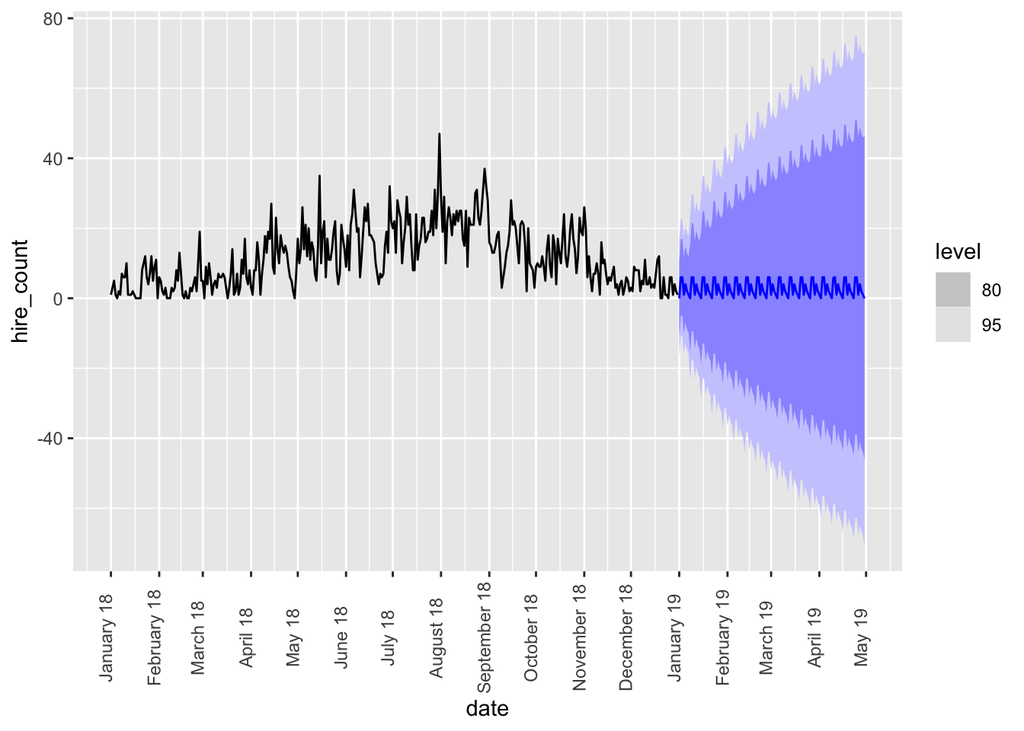

```r
forecast_snaive <- model %>%
  select(snaive_model) %>%
  forecast(h = 120)

forecast_snaive %>%
  autoplot(bikes_filled) +
  scale_x_date(breaks = "1 month",
                   date_labels = "%B %y") +
  theme(axis.text.x = element_text(angle = 90, vjust = 0.1))
```

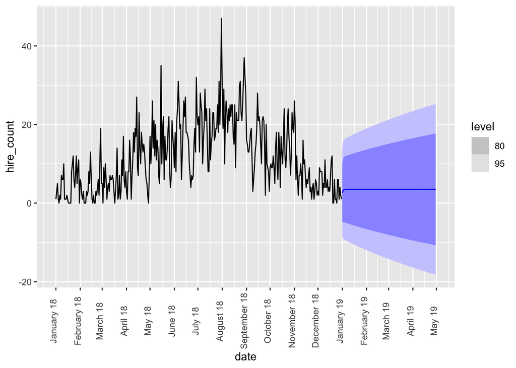

```r
forecast_arima <- model %>%
  select(arima_model) %>%
  forecast(h = 120)

forecast_arima %>%
  autoplot(bikes_filled) +
  scale_x_date(breaks = "1 month",
                   date_labels = "%B %y") +
  theme(axis.text.x = element_text(angle = 90, vjust = 0.1))
```

- SNAIVE seems like the bet model, as it takes into account daily variation but I don’t think any are showing the expected increase in hires as it gets to April and May

### 6

```r
train <- bikes_filled %>%
  filter_index("2018-01-01" ~ "2018-09-30")

model_train <- train %>%    # choo choo
  model(
    mean_model = MEAN(hire_count),
    naive_model = NAIVE(hire_count),
    snaive_model = SNAIVE(hire_count),
    arima_model = ARIMA(hire_count)
  )

forecast_train <- model_train %>%
  forecast(h = 120)
```

```
## Plot variable not specified, automatically selected `.vars = hire_count`
```

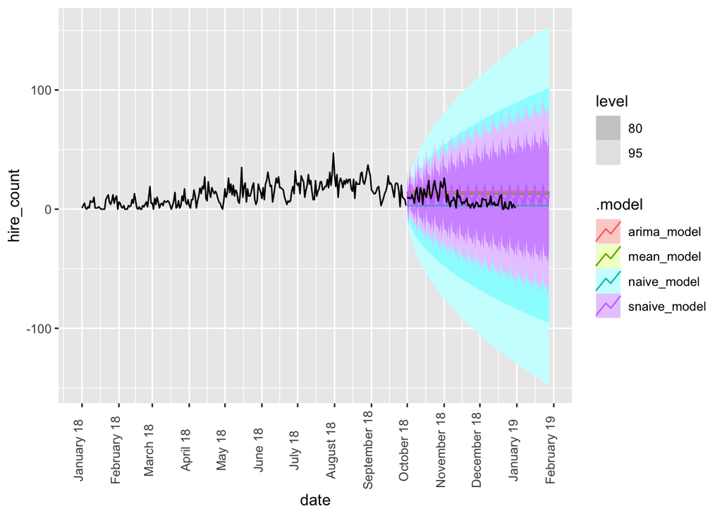

```r
forecast_train %>%
  autoplot(train) +
  autolayer(filter_index(bikes_filled, "2018-10-01" ~ .), colour = "black") +
  scale_x_date(breaks = "1 month",
                   date_labels = "%B %y") +
  theme(axis.text.x = element_text(angle = 90, vjust = 0.1))
```

```r
accuracy(forecast_train, bikes_filled)
```

```
## # A tibble: 4 x 9
##   .model       .type    ME  RMSE   MAE   MPE  MAPE  MASE   ACF1
##   <chr>        <chr> <dbl> <dbl> <dbl> <dbl> <dbl> <dbl>  <dbl>
## 1 arima_model  Test  -5.92  8.60  7.64  -Inf   Inf 1.07  0.608
## 2 mean_model   Test  -4.43  7.55  6.66  -Inf   Inf 0.933 0.603
## 3 naive_model  Test   5.38  8.14  5.99  -Inf   Inf 0.839 0.603
## 4 snaive_model Test  -1.25  7.95  6.38  -Inf   Inf 0.894 0.0577
```

### 8

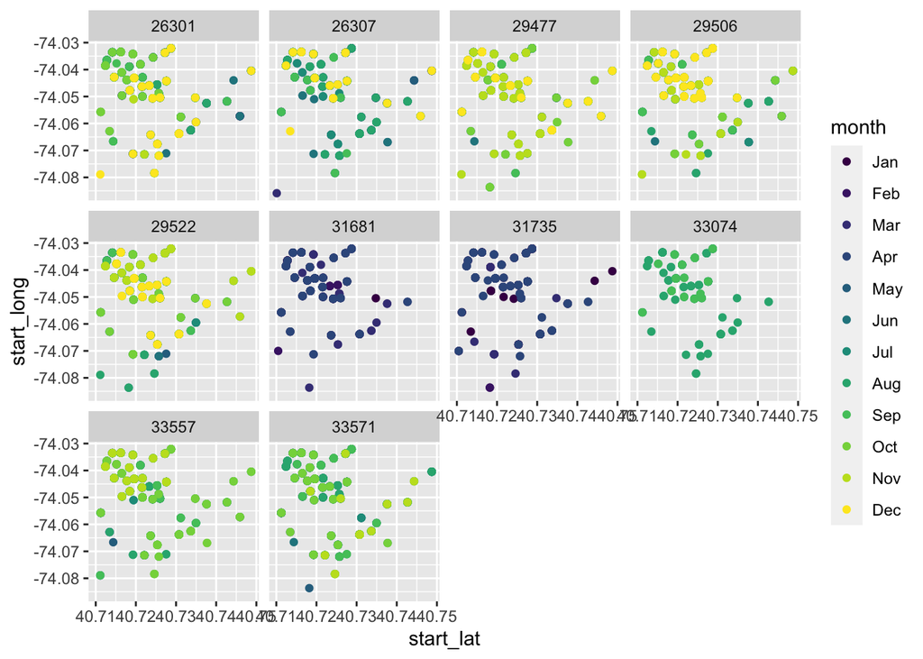

```r
bikes %>%
  ggplot() +
  geom_point(aes(x = start_lat, y = start_long, colour = month), position = "jitter") +
  facet_wrap(~ bike_id)
```

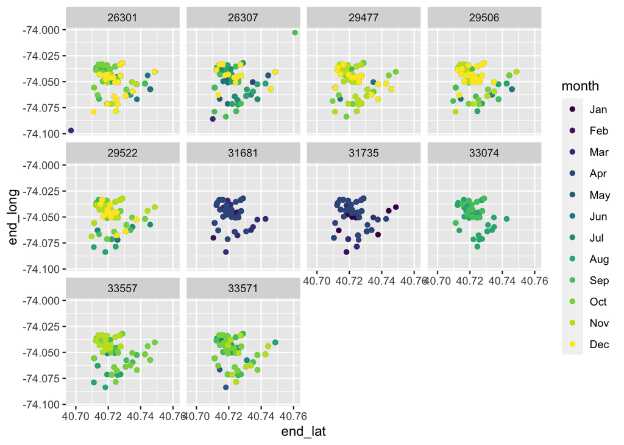

```r
bikes %>%
  ggplot() +
  geom_point(aes(x = end_lat, y = end_long, colour = month), position = "jitter") +
  facet_wrap(~ bike_id)
```

- Seems a wider variety of starting points and more clustering of end points

### 9

```r
library(leaflet)
leaflet(bikes) %>%
  addTiles() %>%
  addMarkers(lng = bikes$start_long, lat = bikes$start_lat, clusterOptions = markerClusterOptions(), clusterId = "start point") #%>%
```

[interactive chart not shown]

```r
  #addMarkers(lng = bikes$end_long, lat = bikes$end_lat, clusterOptions = markerClusterOptions(), clusterId = "end point")
```